# ExxonMobil Valuation Model and Sensitivity Analysis

Syndicate Group 5

21/11/2019

### References

ExxonMobil Financial Data has been obtained from ExxonMobil’s website

All $ values and Balance sheet figures are presented in millions. Date used for market value is company financial year end 31st December 2018 ## ExxonMobil constants ### Operating Margin (EBIT%) Taking figures from 2018 ExxonMobil Accounts Revenue = 290,212 Expenditure before Interest and Tax = 260,025 Margin is therefore: 0.1040171 ### Cost of Capital ExxonMobil WACC is between 8 and 12%. will use a midpoint of 10% for initial analysis, based on the FASB standardised FCFF calculation. ### Reinvestment Rate ExxonMobil had operating profit of 290,212, and had Capex and R&D costs of 25,923 and 1,116 respectively. This gives a reinvestment rate of 27,039/290,212 = 0.0931, assuming reinvestment grows in line with revenue. ### Tax Rate ExxonMobil has a tax reconcilliation in their published accounts, which lists the effective tax rate as 37%

## Mid point estimate

This valuation will assume a 10 year horizon, a 2.4% Oil price growth rate year on year and a 1.0% oil demand increase. Cost of Capital, tax rate and reinvestment rate is assumed to be constant. 2.4% approximates the oil price growth projections of Canada Energy Board https://apps.cer-rec.gc.ca/ftrppndc/dflt.aspx?GoCTemplateCulture=en-CA 1.0% demand growth is taken as reasonable based on this McKinsey report on oil. https://www.mckinsey.com/solutions/energy-insights/global-oil-supply-demand-outlook-to-2035/~/media/231FB01E4937431B8BA070CC55AA572E.ashx

```r
#57.88 is the realised revenue per barrel from 2018 financial statements
oil_prices <- linear_growth_function(57.88, 0.024, 11)
#827m is the number of barrels sold in December 2018
barrels_sold <- linear_growth_function(827, 0.01, 11)
#projected revenue growth of chemical
chemical_revenue_growth <- linear_growth_function(32443, 0.034, 11)
#projected revenue growth of downstream
downstream_revenue_growth <- linear_growth_function(221334, 0.034, 11)

share_price_mid <- wrapped_share_price(oil_prices, barrels_sold, chemical_revenue_growth,
                                       downstream_revenue_growth, Modelconstants, balancesheet, 11, 4237)

share_price_mid_table <- PV_forecast_table(oil_prices, barrels_sold, chemical_revenue_growth, downstream_revenue_growth, 11, Modelconstants)

print(share_price_mid_table)
```

```
##    years revenue_forecast FCFF_value PV_vector
## 1      1         311911.1   17416.37 15833.063
## 2      2         322528.0   18009.19 14883.627
## 3      3         333506.2   18622.19 13991.125
## 4      4         344858.2   19256.05 13152.142
## 5      5         356596.5   19911.49 12363.470
## 6      6         368734.4   20589.24 11622.090
## 7      7         381285.4   21290.06 10925.167
## 8      8         394263.6   22014.73 10270.036
## 9      9         407683.6   22764.08  9654.190
## 10    10         421560.4   23538.92  9075.274
```

```r
print(share_price_mid)
```

```
## [1] 64.6938
```

```r
oil_prices <- linear_growth_function(57.88, 0.024, 11)
barrels_sold <- linear_growth_function(826, 0.05, 11)

share_price_high <- wrapped_share_price(oil_prices, barrels_sold, chemical_revenue_growth, downstream_revenue_growth, Modelconstants, balancesheet, 11, 4237)

print(share_price_high)
```

```
## [1] 128.8691
```

## Low Growth Rate

This uses a growth rate for oil prices of 0.5%, and a demand growth rate of 1%

```r
oil_prices <- linear_growth_function(57.88, 0.005, 11)
barrels_sold <- linear_growth_function(826, 0.01, 11)

share_price_low <- wrapped_share_price(oil_prices, barrels_sold, chemical_revenue_growth, downstream_revenue_growth, Modelconstants, balancesheet, 11, 4237)

print(share_price_low)
```

```
## [1] 55.90265
```

## Negative Growth

This uses a negative growth rate for oil prices of -1%, and a negative growth rate for demand of -1%

```r
oil_prices <- linear_growth_function(57.88, -0.01, 11)
barrels_sold <- linear_growth_function(826, -0.01, 11)

share_price_lowest <- wrapped_share_price(oil_prices, barrels_sold, chemical_revenue_growth, downstream_revenue_growth, Modelconstants, balancesheet, 11, 4237)

print(share_price_lowest)
```

```
## [1] 47.13331
```

## Varying commodity price

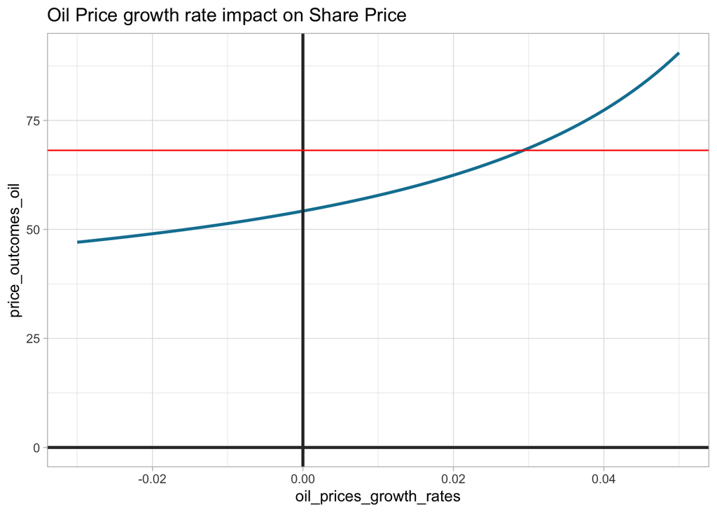

```r
oil_prices_growth_rates <- seq(-3, 5, 0.1)
oil_prices_growth_rates <- oil_prices_growth_rates/100

price_outcomes_oil <- rep(0, length(oil_prices_growth_rates))
###Modelconstants is a vector with Operating Margin, tax rate, reinvestment rate and cost of capital are inputs into our model
Modelconstants <- c(0.1040, 0.37, 0.0931, 0.1)

for (i in oil_prices_growth_rates){
  oil_prices_o <- linear_growth_function(57.88, i, 11)
  barrels_sold_o <- linear_growth_function(826, 0.01, 11)
  share_price_outcome_year <- wrapped_share_price(oil_prices_o, barrels_sold_o, chemical_revenue_growth, downstream_revenue_growth, Modelconstants, balancesheet, 11, 4237)
  price_outcomes_oil[which(oil_prices_growth_rates == i)] <- share_price_outcome_year
}

oil_price_sensitivity <- data.frame(oil_prices_growth_rates, price_outcomes_oil)


oil_price_sensitivity_plot <- ggplot(oil_price_sensitivity,
                                     aes( x = oil_prices_growth_rates,
                                          y = price_outcomes_oil)) +
  geom_line(colour = "#1380A1", size = 1)+
                          geom_hline(yintercept = 0, size = 1, colour="#333333") +
  geom_vline(xintercept = 0, size = 1, colour = '#333333') +
  geom_hline(yintercept = 68.13,
  colour = "red", size = 0.5) +
  theme_light() +
  labs(title="Oil Price growth rate impact on Share Price")

print(oil_price_sensitivity_plot)
```

## Varying the constants - cost of capital

This looks at the impact of the cost of Capital on the valuation of the company, using the mid point growth rates for oil price and demand.

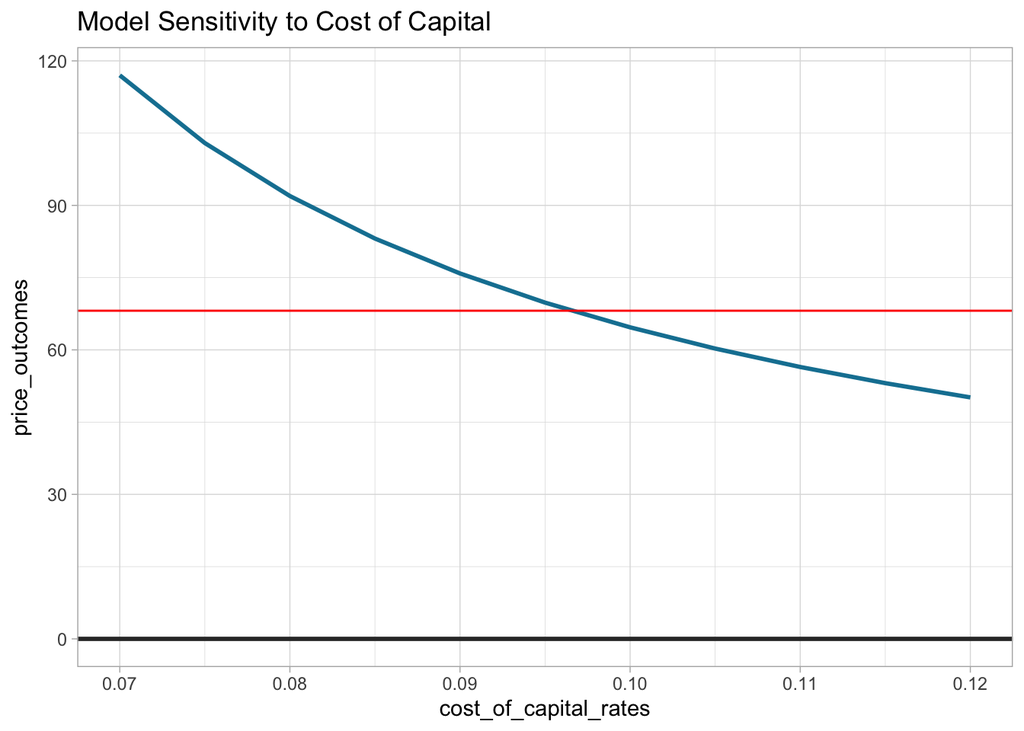

[figure not shown]

## Varying the constants - Operating Margin

This looks at the impact of Operating Margin on the valuation of ExxonMobil, using the mid point growth rates for oil price and demand.

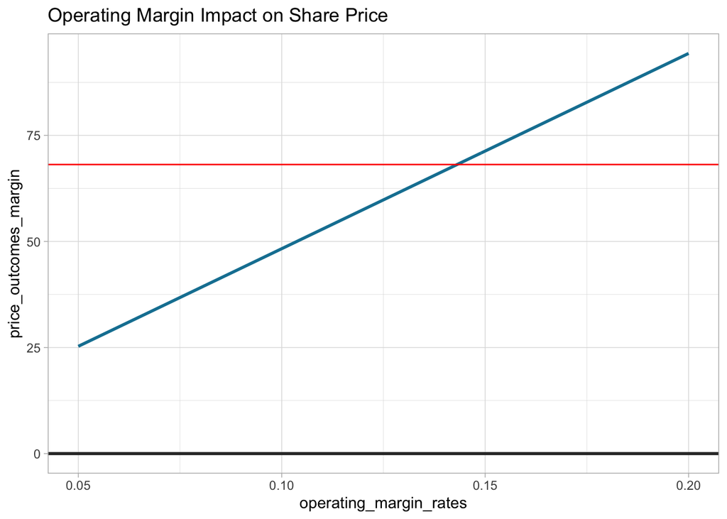

```r
oil_prices <- linear_growth_function(57.88, 0.024, 11)
barrels_sold <- linear_growth_function(826, 0.01, 11)

operating_margin_rates <- seq(5, 20, 0.1)
operating_margin_rates <- operating_margin_rates/100

price_outcomes_margin <- rep(0, length(operating_margin_rates))

for (i in seq_len(length(operating_margin_rates))){
  Modelconstants[1] <- operating_margin_rates[i]
  share_price_outcome <- wrapped_share_price(oil_prices, barrels_sold, chemical_revenue_growth, downstream_revenue_growth, Modelconstants, balancesheet, 11, 4237)
  price_outcomes_margin[i] <- share_price_outcome
}

operating_margin_sensitivity <- data.frame(operating_margin_rates, price_outcomes_margin)

op_margin_plot <- ggplot(operating_margin_sensitivity,
                         aes(x= operating_margin_rates,
                             y= price_outcomes_margin)) +
                          geom_line(colour = "#1380A1", size = 1)+
                          geom_hline(yintercept = 68.13,
                          colour = "red", size = 0.5) +
                          geom_hline(yintercept = 0, size = 1, colour="#333333") +
  theme_light() +
  labs(title="Operating Margin Impact on Share Price")

print(op_margin_plot)
```